# SNA lab 3

Author

Alexandra Rottenkolber

Published

February 2, 2026

# 0 Content of this lab

1. Add on from last week: Assortativity for directed graphs
2. Bipartite and multiplex networks
- 2.1 Bipartite networks
- 2.2 Multiplex networks
3. Community detection
- 3.1 Different algorithms
- 3.2 Evaluating communities
- 3.3 Communities of community detection algorithms
4. Exercises

# 1 Add on from last week: Assortativity for directed graphs

For directed graphs the relationship of nodes is not symmetric (i.e. we distinguish between source and target node), so it is possible to assign different values to the outgoing and the incoming end of the edges. This [paper](https://www.pnas.org/doi/epdf/10.1073/pnas.0912671107) illustrates the case of calculating the assortativity scores for in- and out-degrees in an directed graph. (The case for any other node-level characteristic is equivalent.)

From the above linked paper: “Let $(\alpha, \beta) \in \{in, out\}$ index the degree type, and $j_i^{\alpha}$ and $k_i^{\beta}$ be the $\alpha$- and $\beta$-degree of the source node and target node for edge $i$. Then we define the set of assortativity measures using the Pearson correlation:” (p. 10816)

$$r(\alpha, \beta) =
\frac{\sum_i (j_i^{\alpha} - \bar{j^\alpha}) (k_i^{\beta} - \bar{k^\beta})}
{\sqrt{\sum_i (j_i^{\alpha} - \bar{j^\alpha})^2} \sqrt{\sum_i (k_i^{\beta} - \bar{k^\beta})^2}}$$

*Interpretation*

- $( r_{\text{out-out}}, r_{\text{in-in}} > 0 )$ –> High-degree nodes link to other high-degree nodes (*assortative*).
- $( r_{\text{out-out}}, r_{\text{in-in}} < 0 )$ –> High-degree nodes link to low-degree nodes (*disassortative*).
- $( r_{\text{out-in}}, r_{\text{in-out}} )$ –> measures the *cross-degree correlations* between in-degree and out-degree.

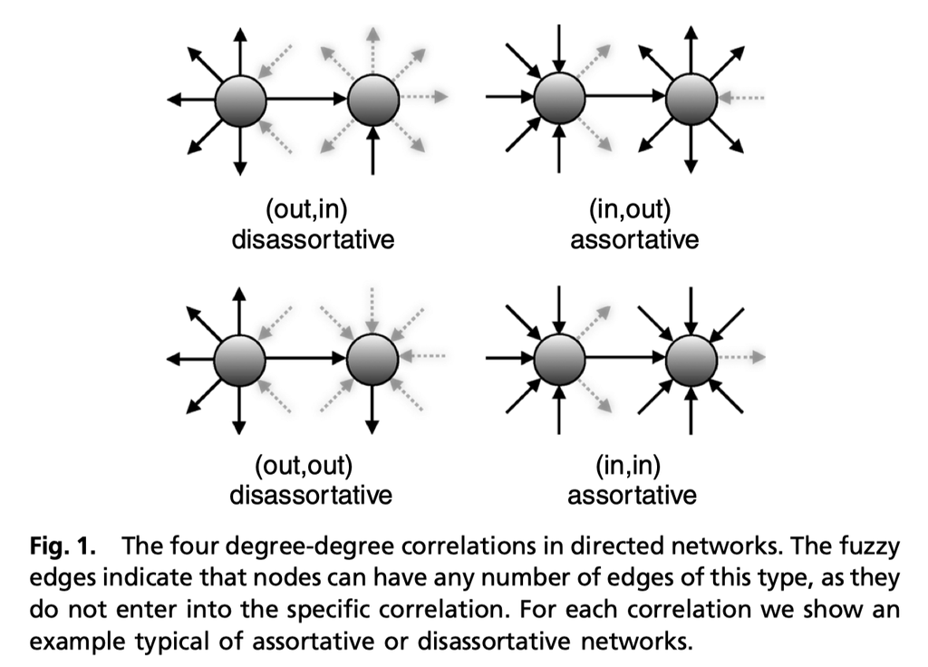

# 2 Multiplex & bipartite networks

## 2.1 Bipartite networks

*This is about different types of nodes*

Let’s imagine we want to analyse the preferences of individuals. We have collected information on people’s favorite brands. We can represent this information as a network two, the only difference is that this time we will have two different types of nodes.

```r
# 1.1) Bipartite networks
bip.mtx <- matrix(data=c(1,0,0,0,
                        1,1,0,0,
                        0,0,1,0,
                        0,1,1,0,
                        1,0,0,1,
                        1,1,0,1,
                        0,0,0,1),
                 nrow=7,ncol=4,byrow = TRUE,
                 dimnames = list(c('Agnes','Birgit','Cecilie','Dan','Elijah','Frank','Gerda'),
                                 c('Spotify','Ikea','Volvo','H&M')))
bip.mtx
```

```
        Spotify Ikea Volvo H&M
Agnes         1    0     0   0
Birgit        1    1     0   0
Cecilie       0    0     1   0
Dan           0    1     1   0
Elijah        1    0     0   1
Frank         1    1     0   1
Gerda         0    0     0   1
```

```r
# From that, we can derive two unipartite (weighted) networks using matrix multiplication
bip.mtx %*% t(bip.mtx)
```

```
        Agnes Birgit Cecilie Dan Elijah Frank Gerda
Agnes       1      1       0   0      1     1     0
Birgit      1      2       0   1      1     2     0
Cecilie     0      0       1   1      0     0     0
Dan         0      1       1   2      0     1     0
Elijah      1      1       0   0      2     2     1
Frank       1      2       0   1      2     3     1
Gerda       0      0       0   0      1     1     1
```

```r
t(bip.mtx) %*% bip.mtx
```

```
        Spotify Ikea Volvo H&M
Spotify       4    2     0   2
Ikea          2    3     1   1
Volvo         0    1     2   0
H&M           2    1     0   3
```

*Questions to you:*

- 1. What does the diagonal capture?
- 2. And the values off the diagonal?

*Your answer:*

- `bip.mtx %*% t(bip.mtx)` …
- `t(bip.mtx) %*% bip.mtx` …

## 2.2 Multiplex networks

*This is about different types of edges*

Now, imagine we have a matrix where different values represent different types of relationship: 1) conflict, 2) distant, … 5) very good. We can aggregreate them into positive and negative ties.

```r
# 1.2) Multiplex network: the special case of signed graphs (positive and negative ties)
w.mtx <- matrix(c(0,5,2,1,2,
                  4,0,0,3,2,
                  2,2,0,4,3,
                  1,2,5,0,3,
                  1,1,5,4,0),
                nrow=5,ncol=5,byrow=TRUE,
                dimnames = list(c('A','B','C','D','E'),c('A','B','C','D','E')))
w.mtx
```

```
  A B C D E
A 0 5 2 1 2
B 4 0 0 3 2
C 2 2 0 4 3
D 1 2 5 0 3
E 1 1 5 4 0
```

```r
# Remember, in week 1 we dichotomized this same network (4 and 5 are positive ties)
dich.mtx <- w.mtx
dich.mtx[dich.mtx %in% 0:3] <- 0
dich.mtx[dich.mtx %in% 4:5] <- 1
dich.mtx
```

```
  A B C D E
A 0 1 0 0 0
B 1 0 0 0 0
C 0 0 0 1 0
D 0 0 1 0 0
E 0 0 1 1 0
```

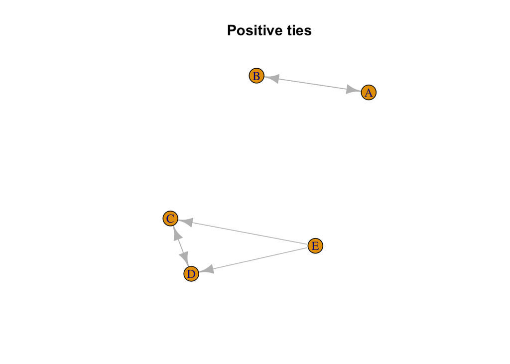

```r
dich.grph <- graph_from_adjacency_matrix(dich.mtx)
plot.igraph(dich.grph,edge.color='grey',main='Positive ties')
```

```r
# Say values of 1 in w.mtx means "conflictive relationship", we can derive another network (on top of dich.mtx)
neg.mtx <- w.mtx
neg.mtx[neg.mtx %in% 2:5] <- 0
neg.mtx
```

```
  A B C D E
A 0 0 0 1 0
B 0 0 0 0 0
C 0 0 0 0 0
D 1 0 0 0 0
E 1 1 0 0 0
```

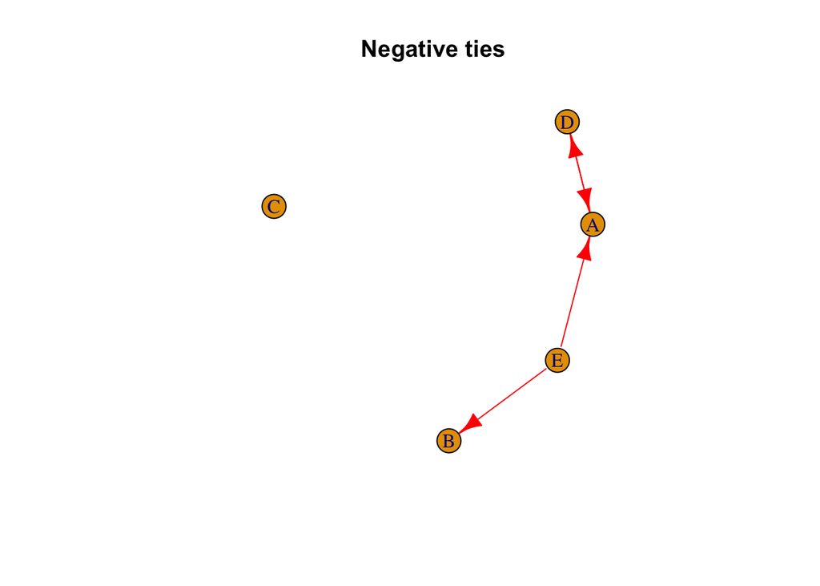

```r
# Turn into igraph format
neg.grph <- graph_from_adjacency_matrix(neg.mtx,mode='directed')
plot.igraph(neg.grph,edge.color='red',main='Negative ties')
```

```r
# We can merge positive and negative ties now
E(neg.grph)$sign <- 'negative'
signed.grph <- igraph::union(dich.grph,neg.grph)
signed.grph
```

```
IGRAPH d1d7b7b DN-- 5 10 --
+ attr: name (v/c), sign (e/c)
+ edges from d1d7b7b (vertex names):
 [1] E->D E->C E->B E->A D->C D->A C->D B->A A->D A->B
```

```r
# Non-negative ties are filled with NA
E(signed.grph)$sign
```

```
 [1] NA         NA         "negative" "negative" NA         "negative"
 [7] NA         NA         "negative" NA
```

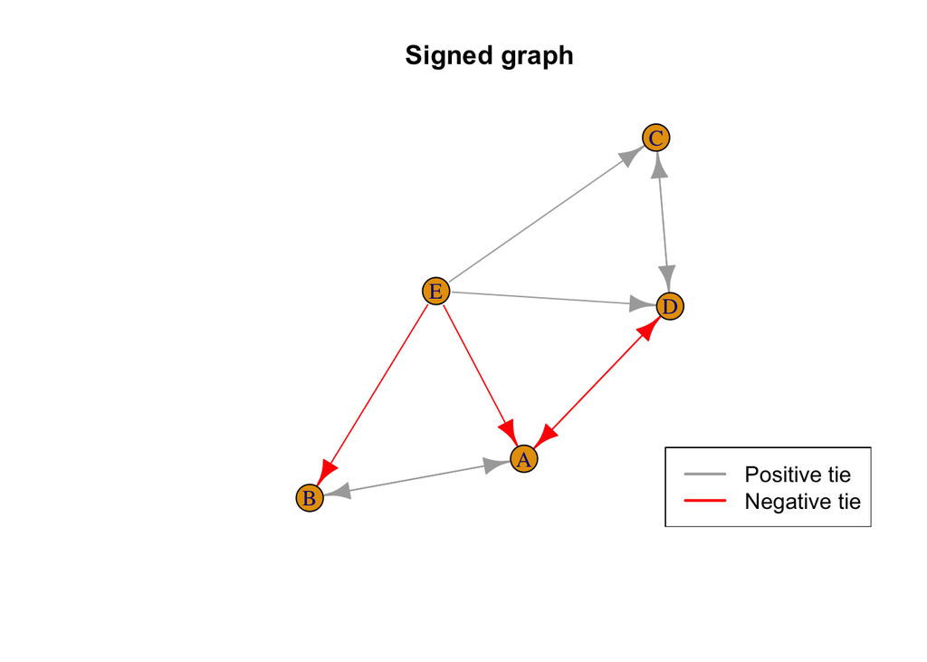

```r
E(signed.grph)$sign[is.na(E(signed.grph)$sign)] <- 'positive'

# Visualization
plot(signed.grph,
     edge.color=ifelse(E(signed.grph)$sign == 'negative','red','darkgrey'),
     main='Signed graph')
legend("bottomright", legend = c('Positive tie','Negative tie'),
       col=c('darkgrey','red'),
       lwd=2, ncol=1)
```

# 3 Community detection

*This is about a networks meso-level structure*

Community detection is an extremely large field of research and has probably received the most attention in the network science discipline overall. The idea behind community detection is basically to identify a network’s mesoscale organisation. Speaking in overly simplistic terms, one can think of a community as a group of nodes which are somewhat more related to each other than to other nodes in the network. (This view is not perfect, but it helps us to get going). Community detection for networks is conceptually similar to data clustering in machine learning/data mining. It can be helpful if you want to find – for example – a group of nodes that would react similarly to a stimulus or if you want to visualise your network in a simpler way.

There are many different approaches out there to find communities: Some use the idea of random walks, some use a group’s internal density, or the similarity to neighbours, etc. The list of approaches is long and hence often yields slightly different results.

To explore different community detection algorithms we will work with the classic Coleman’s Drug Adoption dataset “Innovation among Physicians”. [Here](https://search.r-project.org/CRAN/refmans/spatialprobit/html/CKM.html) you can find the dataset, and [here](https://www.jstor.org/stable/2785979#metadata_info_tab_contents) the corresponding paper. In this study, Coleman et al were interested in how social network ties impact information flow. Therefore, they surveyed physicians in four towns to trace the spread of a medical innovation.

In the lecture, you have learned that community detection is quite a discipline of its own – and that there is also no “one and only” approach for every problem.

## 3.1 Different algorithms

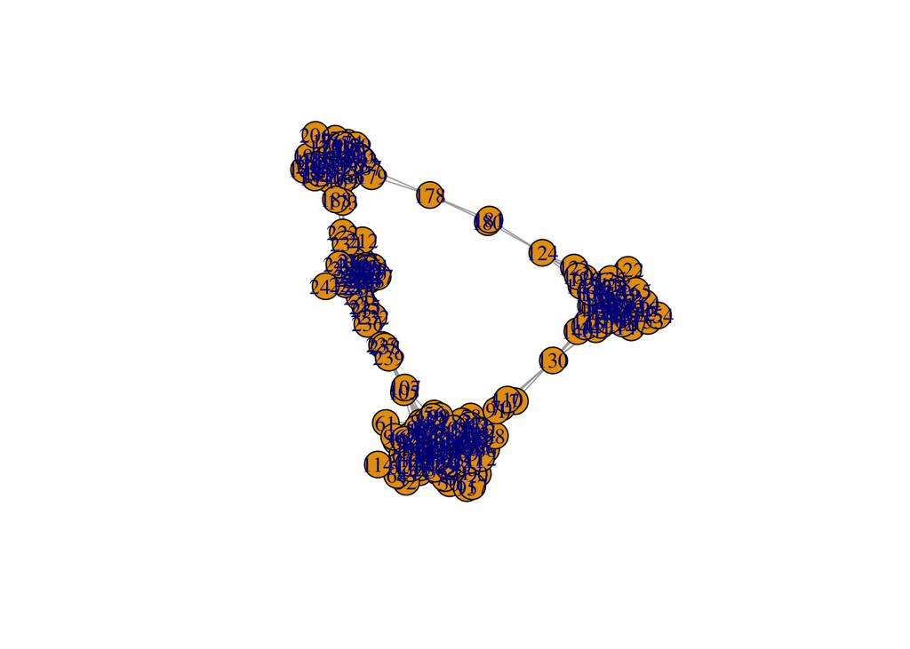

```r
df1 <- read.csv("../session_3/data/data_1.txt", header = FALSE, sep = " ") # edgelist
mtx1 <- as.matrix(df1)
grph1 <- graph_from_edgelist(mtx1, directed = FALSE)

plot(grph1)
```

```r
# GIRVAN-NEWMAN
# Idea: removing edges of highest betweenness one after the other
gn_clustering <- cluster_edge_betweenness(grph1,modularity=TRUE,membership=TRUE)
#gn_clustering$modularity
length(gn_clustering)
```

```
[1] 7
```

```r
# MOODY-WHITE
blocks_clustering <- cohesive_blocks(grph1)
length(blocks_clustering$blocks)
```

```
[1] 18
```

```r
# WALKTRAP
# based on random walks
walk_clustering <- cluster_walktrap(grph1,step=10)
length(walk_clustering)
```

```
[1] 4
```

```r
# LOUVAIN
louvain_clustering <- cluster_louvain(grph1)
length(louvain_clustering)
```

```
[1] 6
```

```r
# FAST-GREEDY
fast_greedy_clustering <- cluster_fast_greedy(grph1)
length(fast_greedy_clustering)
```

```
[1] 5
```

```r
# LEADING EIGENVECTOR
leading_eigen_clustering <- cluster_leading_eigen(grph1)
length(leading_eigen_clustering)
```

```
[1] 6
```

```r
# INFOMAP
infomap_clustering <- cluster_infomap(grph1)
length(infomap_clustering)
```

```
[1] 10
```

```r
# LABEL PROPAGATION
label_prop_clustering <- cluster_label_prop(grph1)
length(label_prop_clustering)
```

```
[1] 5
```

```r
# LABEL PROPAGATION
spinnglass_clustering <- cluster_spinglass(grph1)
length(spinnglass_clustering)
```

```
[1] 7
```

```r
knitr::opts_chunk$get('fig.retina')
```

```
[1] 2
```

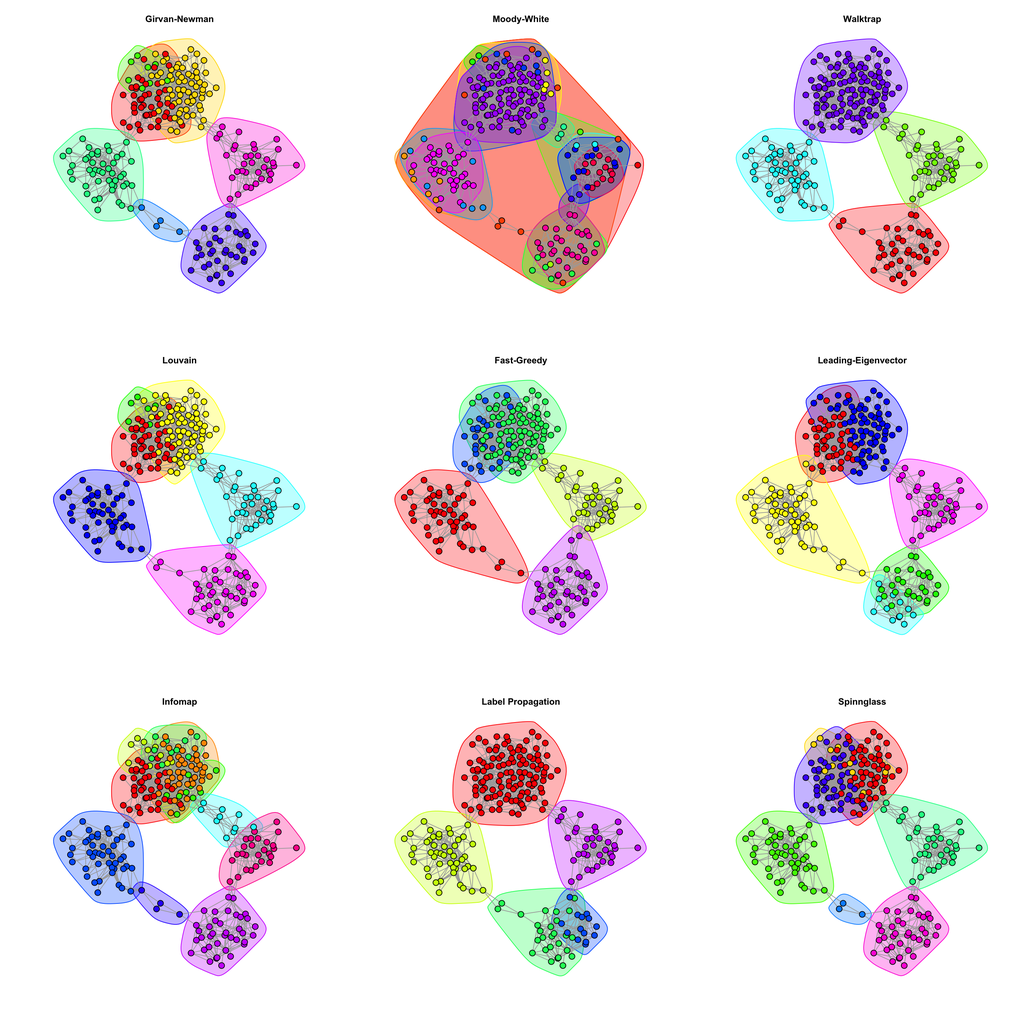

```r
# plot communities
pos = layout_with_kk(grph1)

par(mfrow=c(3,3)) # plots side by side

colors <- rainbow(max(membership(gn_clustering)))
plot(grph1,
     vertex.color = colors[membership(gn_clustering)],
     vertex.border = colors[membership(gn_clustering)],
     vertex.shape = 'circle',
     vertex.size = 5,
     vertex.label = "",
     main='Girvan-Newman',
     mark.groups = gn_clustering,
     mark.col = rainbow(length(gn_clustering), alpha = 0.3),
     layout = pos)

membership_vector <- rep(NA, vcount(grph1))
membership <- blocks(blocks_clustering)
for (i in seq_along(membership)) {
  membership_vector[membership[[i]]] <- i
}
colors <- rainbow(max(membership_vector))
plot(grph1,
     vertex.color = colors[membership_vector],
     vertex.border = colors[membership_vector],
     vertex.shape = 'circle',
     vertex.size = 5,
     vertex.label = "",
     main='Moody-White',
     mark.groups = blocks_clustering$blocks,
     mark.col = rainbow(length(blocks_clustering$blocks), alpha = 0.3),
     layout = pos)

colors <- rainbow(max(membership(walk_clustering)))
plot(grph1,
     vertex.color = colors[membership(walk_clustering)],
     vertex.border = colors[membership(walk_clustering)],
     vertex.shape = 'circle',
     vertex.size = 5,
     vertex.label = "",
     main='Walktrap',
     mark.groups = walk_clustering,
     mark.col = rainbow(length(walk_clustering), alpha = 0.3),
     layout = pos)

colors <- rainbow(max(membership(louvain_clustering)))
plot(grph1,
     vertex.color = colors[membership(louvain_clustering)],
     vertex.border = colors[membership(louvain_clustering)],
     vertex.shape = 'circle',
     vertex.size = 5,
     vertex.label = "",
     main='Louvain',
     mark.groups = louvain_clustering,
     mark.col = rainbow(length(louvain_clustering), alpha = 0.3),
     layout = pos)

colors <- rainbow(max(membership(fast_greedy_clustering)))
plot(grph1,
     vertex.color = colors[membership(fast_greedy_clustering)],
     vertex.border = colors[membership(fast_greedy_clustering)],
     vertex.shape = 'circle',
     vertex.size = 5,
     vertex.label = "",
     main='Fast-Greedy',
     mark.groups = fast_greedy_clustering,
     mark.col = rainbow(length(fast_greedy_clustering), alpha = 0.3),
     layout = pos)

colors <- rainbow(max(membership(leading_eigen_clustering)))
plot(grph1,
     vertex.color = colors[membership(leading_eigen_clustering)],
     vertex.border = colors[membership(leading_eigen_clustering)],
     vertex.shape = 'circle',
     vertex.size = 5,
     vertex.label = "",
     main='Leading-Eigenvector',
     mark.groups = leading_eigen_clustering,
     mark.col = rainbow(length(leading_eigen_clustering), alpha = 0.3),
     mark.border = colors,
     layout = pos)

colors <- rainbow(max(membership(infomap_clustering)))
plot(grph1,
     vertex.color = colors[membership(infomap_clustering)],
     vertex.border = colors[membership(infomap_clustering)],
     vertex.shape = 'circle',
     vertex.size = 5,
     vertex.label = "",
     main='Infomap',
     mark.groups = infomap_clustering,
     mark.col = rainbow(length(infomap_clustering), alpha = 0.3),
     mark.border = colors,
     layout = pos)

colors <- rainbow(max(membership(label_prop_clustering)))
plot(grph1,
     vertex.color = colors[membership(label_prop_clustering)],
     vertex.border = colors[membership(label_prop_clustering)],
     vertex.shape = 'circle',
     vertex.size = 5,
     vertex.label = "",
     main='Label Propagation',
     mark.groups = label_prop_clustering,
     mark.col = rainbow(length(label_prop_clustering), alpha = 0.3),
     mark.border = colors,
     layout = pos)

colors <- rainbow(max(membership(spinnglass_clustering)))
plot(grph1,
     vertex.color = colors[membership(spinnglass_clustering)],
     vertex.border = colors[membership(spinnglass_clustering)],
     vertex.shape = 'circle',
     vertex.size = 5,
     vertex.label = "",
     main='Spinnglass',
     mark.groups = spinnglass_clustering,
     mark.col = rainbow(length(spinnglass_clustering), alpha = 0.3),
     mark.border = colors,
     layout = pos)
```

```r
par(mfrow=c(1,1))
```

## 3.2 Evaluating communities

Probably, you have observed that the results returned were quite diverse. Was there even a single pair of community detection algorithms that returned exactly the same partitions?

There are different ways to continue from here. One is to evaluate the partitioning based on some quality measure. One example of such a measure is the “modularity score” (a very popular approach). Another approach would be to calculate the “Normalised Mutual Information”. We will use the modularity score for the time being.

The modularity looks at the internal density of a community and compares it to a random expectation (i.e. comparing the observed number of edges inside a community to the expected number of edges within a community (configuration model)).

The modularity score can take on values between -0.5 and 1. It is positive if a community has more edges than expected by chance; it equals zero if there are exactly as many edges present in a partition as a null model would suggest; and is negative if nodes in a partition are connected by fewer edges than expected.

Mathematically, the modularity can be expressed as follows:

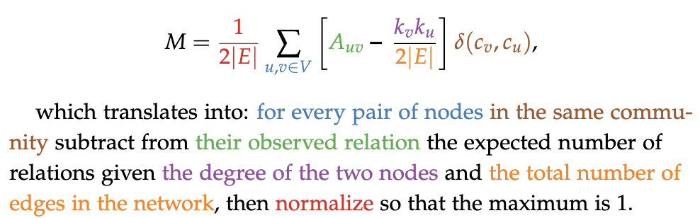

Let’s have a look at the modularity scores of our community detection…

```r
modularity_scores <- c(
  louvain = modularity(grph1, membership(louvain_clustering)),
  walktrap = modularity(grph1, membership(walk_clustering)),
  infomap = modularity(grph1, membership(infomap_clustering)),
  fast_greedy = modularity(grph1, membership(fast_greedy_clustering)),
  louvain = modularity(grph1, membership(leading_eigen_clustering)),
  girvan_newman = modularity(grph1, membership(gn_clustering)),
  cohesive_blocks = modularity(grph1, membership_vector),
  label_propagation = modularity(grph1, membership(label_prop_clustering)),
  spinnglass = modularity(grph1, membership(spinnglass_clustering))
)

modularity_scores
```

```
          louvain          walktrap           infomap       fast_greedy
        0.6782984         0.6502987         0.6664202         0.6558528
          louvain     girvan_newman   cohesive_blocks label_propagation
        0.6383114         0.6743160         0.5116112         0.6345782
       spinnglass
        0.6809673
```

## 3.3 Communities of community detection algorithms

We are still pondering about the same question. Different algorithms, different results. What to do about that?

Figure 4 displays an overview of communities among different community detection algorithms (nodes represent algorithms). Nodes are connected if two community detection algorithms return similar results.

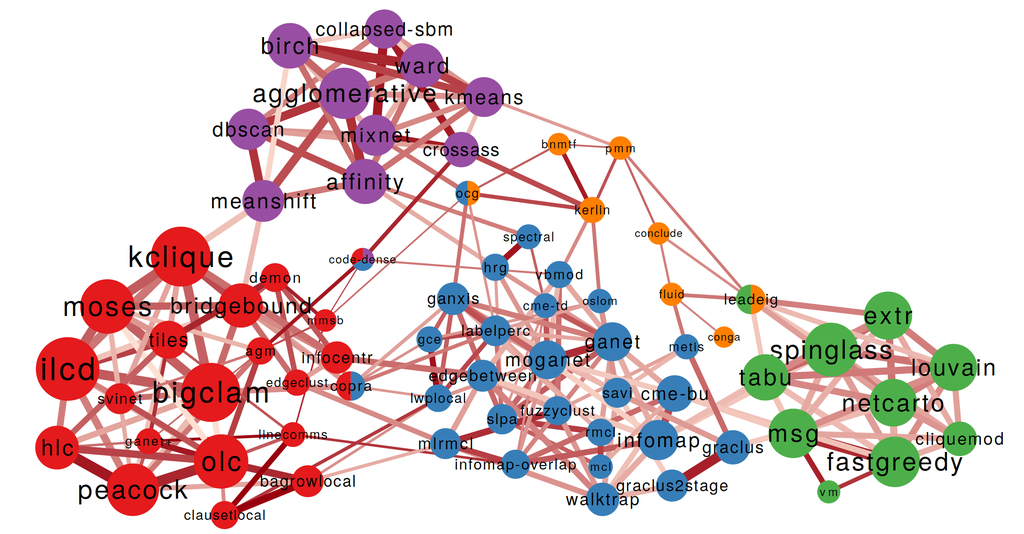

**Figure 4: Different clusters of community detection algorithms (taken from Coscia (2021), p. 436).**

The colours indicated different communities in the network.

- red cluster: algorithms allowing for overlapping communities
- blue cluster: infomap and label propagation approaches
- purple cluster: methods that do not use the “internal density” anymore but instead the idea of “neighbour similarity” (e.g. kmeans)
- green cluster: optimisation of a quality indicator (e.g. modularity score) (e.g. Louvain)

The big question is always: How to find the optimal solution for my network? How can we maximise the chance of finding the best partitions for our networks?

One approach – inspired by an observation from machine learning which can be summarised as ‘averaging several simple models often yields better accuracy than constructing the most sophisticated model possible’ – is called “[consensus clustering](https://www.nature.com/articles/srep00336)”.

The idea is as simple as the results are compelling: Run several clustering algorithms (also the same one many times) and average the results. Just keep in mind to not apply this method blindly: Make sure the results you are averaging stem from an internally consistent ensemble of clustering algorithms (meaning: all algorithms apply the same logic. For example, don’t mix flow-based (infomap and co) with density optimisation algorithms, etc. (methods from the green group with the red one, or purple, or … one))

# 4 Exercises

## 4.1 Exercise 1: Blog posts

For this exercise, we will use a dataset from this [article](https://dl.acm.org/doi/pdf/10.1145/1134271.1134277?casa_token=4s9yFKDhE2oAAAAA:8k4b1uqozQwxn4DBIg0lDn9v0DnP07KxgYMyPYRtvmlwdf3i-8yMfpd41C74GAkFuGiRRKb9OYSuxw). The dataset contains front-page hyperlinks (edges) between blogs (nodes) in the context of the 2004 US election (directed network). The dataset is available [here](http://konect.cc/networks/moreno_blogs/).

1. Read in the data.
2. Investigate whether there is assortative mixing between right- and left-leaning blogs.

```r
#YOUR CODE
```

```r
#YOUR CODE
```

## 4.2 Exercise 2: The friendship paradox

For this exercise, we will use the data from the following [paper](https://dl.acm.org/doi/pdf/10.1145/1592665.1592675): Viswanath, B., Mislove, A., Cha, M., & Gummadi, K. P. (2009). On the evolution of user interaction in Facebook. Proceedings of the 2nd ACM Workshop on Online Social Networks, 37–42.

You can find it in the data folder under the name `data-facebook.txt`.

1. Read in the data, and construct your graph.

```r
#YOUR CODE
```

2. This time, we are not interested in the assortativity by a categorical node attribute (as right- or left-leaning), but rather in assortativity by number of friends (i.e. the degree assortativity). Generate a plot that shows the average number of the friends of a person’s friends plotted against the number of this person’s friends. Add the identity line.

```r
#YOUR CODE
```

3. Persons above the identity line have fewer friends than their average neighbour, while nodes below the identity line have more. The friendship paradox states that most nodes have fewer friends than their friends’ average. Can you check, whether the friendship paradox is also at play in the Facebook network? (Hint: One needs to count the number of nodes above and below the identity line, and to compare the size of both groups.)

```r
#YOUR CODE
```

4. Calculate the degree assortativity.

```r
#YOUR CODE
```